# A model to predict the result of the COVID exam

Diego Liberato Souza

21/04/2020

# 1 Objective

The objective of this kernel is to develop a model to predict the results of the COVID exam, taking care of certain details that involve the design of medical examinations.The dataset used is available in [Kaggle](https://www.kaggle.com/einsteindata4u/covid19) and was made available by hospital Albert Einstein.

# 2 Strategy Used

# 3 Loading packages and importing data

```r
library(openxlsx)
library(fastDummies)
library(tidyverse)
library(Rtsne)
library(Hmisc)
library(factoextra)
library(caret)
library(permute)
library(xgboost)
library(h2o)
library(stringi)
library(FactoMineR)
library(e1071)
library(plotROC)
library(ROCR)
library(ggrepel)
library(hrbrthemes)
library(GGally)
library(knitr)
library(kableExtra)
library(corrplot)
```

# 4 Data cleaning and manipulation

The first thing I did was to separate the categorical variables from the numerical variables, since I treated them differently:

```r
non_numerical_corona <- corona[, !(names(corona) %in% names(corona %>% select_if(is.numeric)))]

numerical_corona <- cbind(select(corona, Patient.ID), corona[, (names(corona) %in% names(corona %>% select_if(is.numeric)))])
```

## 4.1 Categorical data

I replaced every NA values by the label *“No exam”*:

```r
for (i in c(3:37)){

  non_numerical_corona[,i] <- ifelse(is.na(non_numerical_corona[,i]), "no exam", non_numerical_corona[,i])

}
```

The categorical data was transformed in dummies, and the first dummie of every categorial variable was removed:

```r
non_numerical_corona <- dummy_cols(non_numerical_corona, select_columns = colnames(non_numerical_corona)[3:37], remove_selected_columns = TRUE, remove_first_dummy = TRUE)
```

## 4.2 Numerical data

```r
for (i in c(6:30, 34:40, 42:44, 46, 51, 52,54:72, 74, 75)){

  quantiles <- quantile(numerical_corona[,i], prob = seq(0, 1, length = 5), type = 5, na.rm = TRUE)
  numerical_corona[,i] <- cut(numerical_corona[,i], breaks = as.numeric(quantiles))
  numerical_corona[,i] <- as.character(numerical_corona[,i])



}
```

Then the missing values were replaced by *“No exam”*:

```r
for (i in c(2:75)){

  numerical_corona[,i] <- ifelse(is.na(numerical_corona[,i]), "no exam", numerical_corona[,i])

}
```

Similar to what was done with categorical variables, numerical variables (now transformed into discrete ones) were transformed into dummies. The other numerical variables that were not broken into quartiles due to low variance (or low number of observations), were also transformed into dummies, since most of them repeated the same values for several observations:

```r
numerical_corona <- dummy_cols(numerical_corona, select_columns = colnames(numerical_corona)[6:75], remove_selected_columns = TRUE, remove_first_dummy = TRUE)
```

I joined the numerical and categorical data, creating the final database that will be used in the dimensionality reduction, after that I exclude the intermediate databases used:

```r
corona_final <- left_join(non_numerical_corona, numerical_corona)


rm(corona, numerical_corona, non_numerical_corona)
```

# 5 Dimensionality Reduction

After transforming all variables into dummies, there are a large number of variables available, we went from 111 variables to 444 variables. I believe that 111 variables is already a large number of variables for the number of observations that the database has, with 444 variables the best strategy is to use dimensionality reduction.

## 5.1 PCA

The first method applied was PCA, however I recognize that this is not the most suitable method for a database full of dummies. My goal was to observe the performance of the algorithms using the principal components produced by the PCA and compare it with the other dimensionality reduction methods. The PCA was applied and the variables were centralized:

```r
pca_output <- prcomp(corona_final[,-c(1,2)], center=TRUE, scale=FALSE)
```

The plot below shows the principal components and the percentage of variation explained by each one.

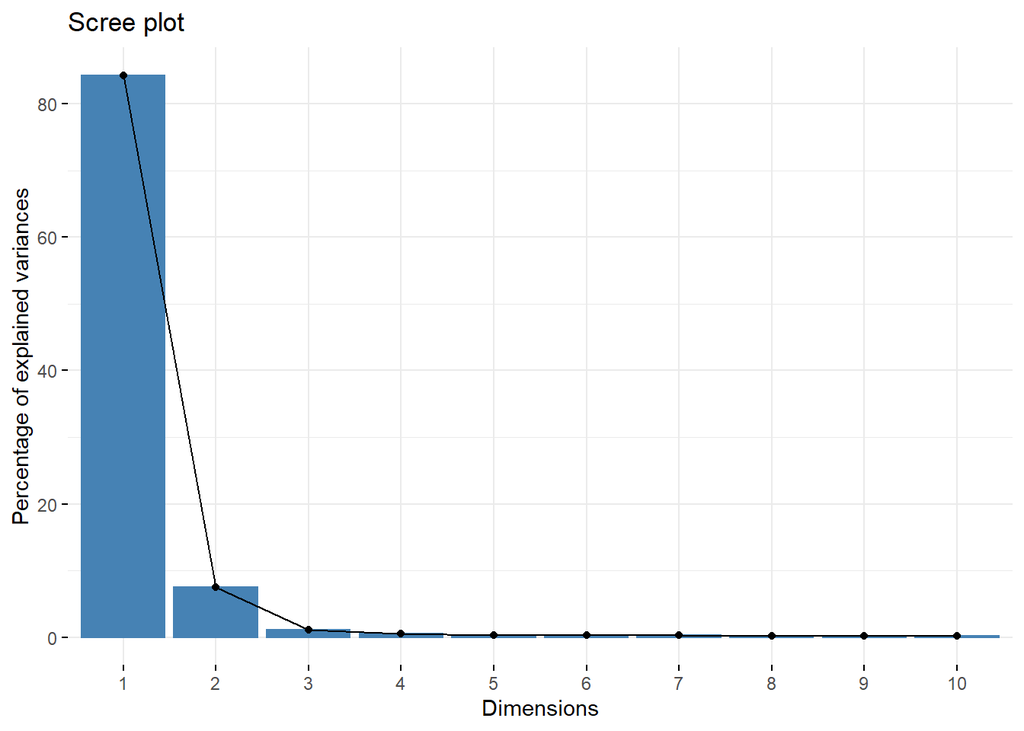

```r
fviz_eig(pca_output)
```

A dataset was created using the first 10 components, and the patient’s label and id were joined to the data:

```r
pca_data <- data.frame(pca_output$x[,c(1:10)], corona_final %>% select(exam = `SARS-Cov-2.exam.result`, Patient.ID))

rm(pca_output)
```

## 5.2 TSNE

I believe that the most difficult aspect to deal with tsne is the perplexity hyperparameter, which balance the attention between local and global aspects of the dataset. The best way to inspect the best perplexity value is by testing multiple values and viewing plots to understand whether this perplexity value separated the data well in two dimensions. But before that, it is important to define the value of the number of interactions that will be used. For this, I applied a tsne model and plotted the total KL-Divergence Cost (which we want to minimize), over the iterations (each unit of the x-axis is measured in 50 interactions):

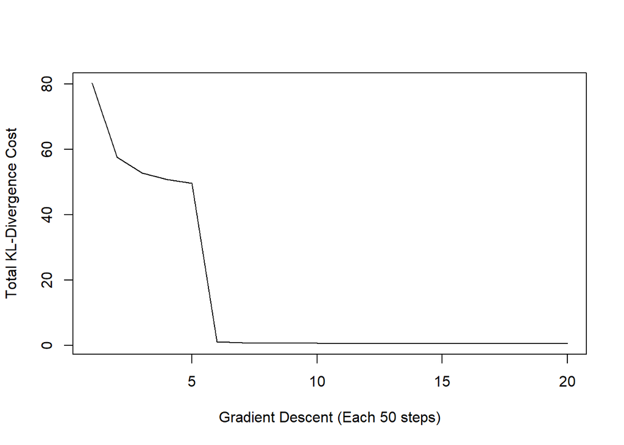

```r
set.seed(666)

tsne <- Rtsne(corona_final[,-c(1,2)], check_duplicates = FALSE, max_iter = 1000)

plot(tsne$itercosts, type = "l",  ylab="Total KL-Divergence Cost", xlab="Gradient Descent (Each 50 steps)")
```

It is observed that the number of optimal interactions is 300 (6 multiplied by 50), so we will use this value to test the different perplexities. First, we will test perplexity values from 1 to 100, comparing how the observations are separated into different perplexity values:

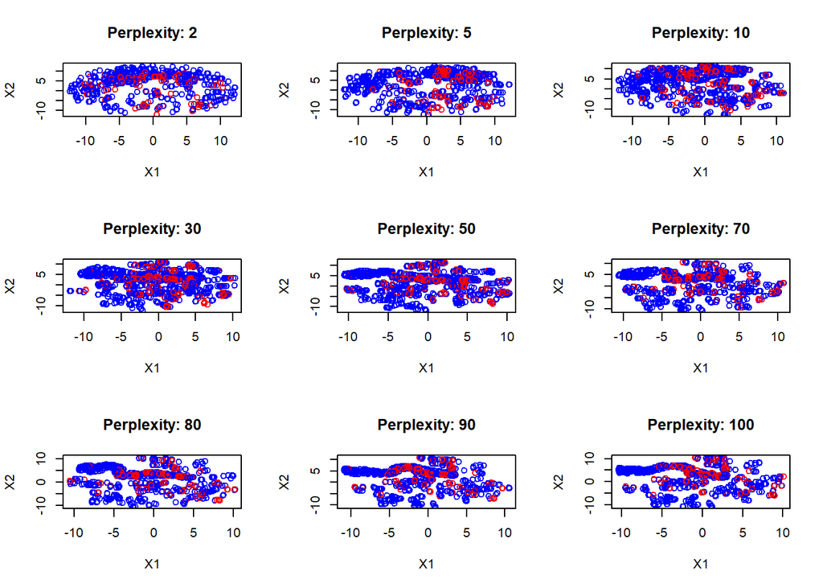

```r
par(mfrow=c(3,3))

perplexity <- c(2, 5, 10, 30, 50, 70, 80, 90, 100)

for (i in perplexity){

  set.seed(666)

  tsne <- Rtsne(corona_final[,-c(1,2)], check_duplicates = FALSE, max_iter = 300, perplexity = i)

  tsne_data <- data.frame(tsne$Y,
                          corona_final %>%
                            select(exam = `SARS-Cov-2.exam.result`)) %>%
    mutate(color = ifelse(exam == "positive","Red", "Blue"))

    plot(tsne_data$X1, tsne_data$X2, col = tsne_data$color, xlab = "X1", ylab = "X2",
       main = paste("Perplexity:", i))

}
```

After that, we will test perplexity values from 150 to 550, comparing how the observations are separated into different perplexity values:

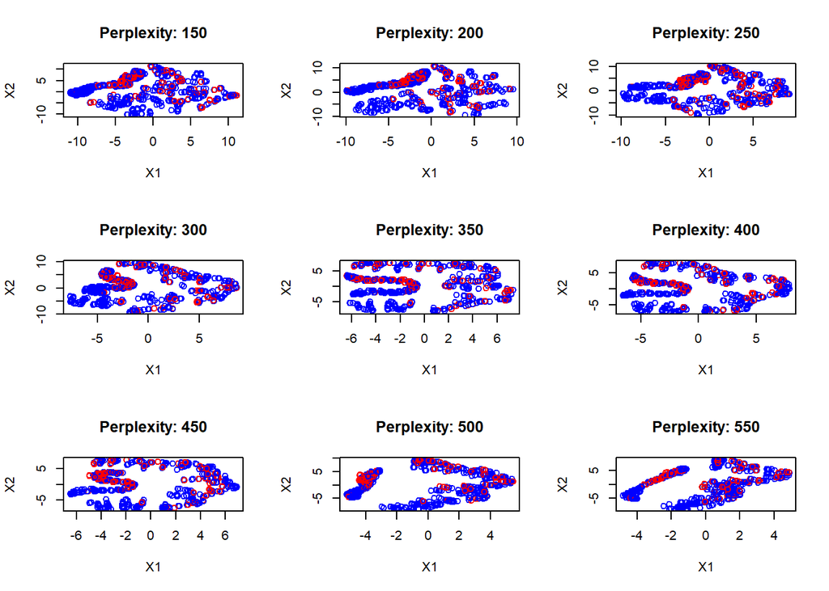

```r
par(mfrow=c(3,3))

perplexity <- c( 150, 200, 250, 300, 350, 400, 450, 500, 550)

for (i in perplexity){

  set.seed(666)

  tsne <- Rtsne(corona_final[,-c(1,2)], check_duplicates = FALSE, max_iter = 300, perplexity = i)

  tsne_data <- data.frame(tsne$Y,
                          corona_final %>%
                            select(exam = `SARS-Cov-2.exam.result`)) %>%
    mutate(color = ifelse(exam == "positive","Red", "Blue"))

  plot(tsne_data$X1, tsne_data$X2, col = tsne_data$color, xlab = "X1", ylab = "X2",
       main = paste("Perplexity:", i))

}
```

```r
rm(perplexity)
```

Visually, data tends to become more crowded in cases where perplexity is low (less than 70) or high (greater than 300). Thus, deciding to test 4 different perplexities values: 100,150, 200 and 250. I produced databases from the 2-dimensional and 3-dimensional tsne, making 8 configurations of applied tsne and 8 databases to test the algorithms:

```r
dim_red_data <- list()

for (i in c(100, 150, 200, 250)){

  for (j in c(2,3)){

    set.seed(666)

    tsne <- Rtsne(corona_final[,-c(1,2)], check_duplicates = FALSE, max_iter = 300, perplexity = i, dims = j)


    tsne_result <- data.frame(tsne$Y,
                                    corona_final %>%
                                      select(exam = `SARS-Cov-2.exam.result`,
                                             Patient.ID))

    dim_red_data <- append(dim_red_data, list(tsne_result))


  }


}
```

## 5.3 GLRM

The third Dimensionality Reduction model I applied was GLRM, and I chose the value of 10 for the hyperparameter k of the model, reducing the data to 10 dimensions. I had to change the name of the columns to random names, because the h2o.glrm function had problems with the variable names. At the end, I created a database with the GLRM results and merged the patient ID information and the exam result:

```r
# - Initiating H2O

h2o.init()

# - Selecting data to dimensionality reduction

glrm_adjusted <- corona_final[,-c(1,2)]

# - Changing colnames to avoid problems in the algorithm

colnames(glrm_adjusted) <- stringi::stri_rand_strings(442,4)

# - Transfering data to h2o

corona_final.hex <- as.h2o(glrm_adjusted, "corona_final.hex")

# - Applyng GLRM model


model_glrm <- h2o.glrm(training_frame = corona_final.hex,
                       cols = 1:ncol(glrm_adjusted), k = 10,
                       max_iterations = 1000, seed = 666)



# - Creating data with glrm results


glrm_data <- cbind(as.data.frame(h2o.getFrame(model_glrm@model$representation_name)),
                   corona_final %>% select(exam = `SARS-Cov-2.exam.result`, Patient.ID))
```

Together with the list containing the data resulting from the TSNE, I have added the data from the PCA and GLRM to the list:

```r
# - Bringing glrm data and pca data to tsne datas

dim_red_data <- append(dim_red_data, list(pca_data))
dim_red_data <- append(dim_red_data, list(glrm_data))

# Removing dataframes that we will not use

rm(corona_final.hex, glrm_adjusted, glrm_data, model_glrm, pca_data, tsne, tsne_result)
```

# 6 Selecting the best data

To select the dimensionality reduction method to be used, 5 different algorithms were applied to all available databases. The choice of these algorithms was not careful, but it sought to bring a diversity in the way these algorithms relate input to output, whether using techniques such as maximum likelihood, boosting, distance between observations, etc. The following algorithms were applied: Adaboost (ada), Logistic Regression (glmnet), Regularized Discriminant Analysis (rda), KNN (knn) and SVM (svm). For all models, scale and center were applied in pre-processing, 5-fold cross validation was used, oversampling was applied (using the SMOTE method) and hyperparamenter tuning was performed (some models with the grid already defined by the caret package and others customized). From the application of each algorithm in each of the databases, the maximum AUC that the algorithm obtained during hyperparameter tuning and the average AUC were calculated. The code below shows the application of all selected algorithms in each of the databases:

```r
# ADABOOST

max_auc <- c()
mean_auc <- c()

for (i in 1:10){

# Create training and test data

data <- data.frame(dim_red_data[i])

set.seed(666)
trainRowNumbers <- createDataPartition(shuffle(data$exam), p=0.80, list=FALSE)

# Create the training  dataset

train <- data[trainRowNumbers,]

# Create the test dataset

test <- data[-trainRowNumbers,]

set.seed(666)

model <- train(
  exam ~ ., train %>% select(-Patient.ID),
  method = "ada",
  preProcess = c("scale", "center"),
  trControl = trainControl(
    method = "cv",
    search = "grid",
    number = 5,
    verboseIter = TRUE,
    classProbs = TRUE,
    summaryFunction = twoClassSummary,
    sampling = "smote"
  ),
  metric = 'ROC')



max_auc <- c(max_auc, max(model$results$ROC))
mean_auc <- c(mean_auc, mean(model$results$ROC))

}

adaboost_results <- data.frame(alg = rep("adaboost", 10),
           model = c("tsne_100_2", "tsne_100_3", "tsne_150_2", "tsne_150_3", "tsne_200_2", "tsne_200_3",
                     "tsne_250_2", "tsne_250_3", "pca", "glrm"),
           max_auc = max_auc,
           mean_auc = mean_auc)



# GLM

max_auc <- c()
mean_auc <- c()

for (i in 1:10){

  # Create training and test data

  data <- data.frame(dim_red_data[i])

  set.seed(666)
  trainRowNumbers <- createDataPartition(shuffle(data$exam), p=0.80, list=FALSE)

  # Create the training  dataset

  train <- data[trainRowNumbers,]

  # Create the test dataset

  test <- data[-trainRowNumbers,]

  set.seed(666)

  model <- train(
    exam ~ ., train %>% select(-Patient.ID),
    method = "glmnet",
    preProcess = c("scale", "center"),
    trControl = trainControl(
      method = "cv",
      search = "grid",
      number = 5,
      verboseIter = TRUE,
      classProbs = TRUE,
      summaryFunction = twoClassSummary,
      sampling = "smote"
    ),
    metric = 'ROC')



  max_auc <- c(max_auc, max(model$results$ROC))
  mean_auc <- c(mean_auc, mean(model$results$ROC))

}

glm_results <- data.frame(alg = rep("glm", 10),
                              model = c("tsne_100_2", "tsne_100_3", "tsne_150_2", "tsne_150_3", "tsne_200_2", "tsne_200_3",
                                        "tsne_250_2", "tsne_250_3", "pca", "glrm"),
                              max_auc = max_auc,
                              mean_auc = mean_auc)



# Discriminant Analysis

max_auc <- c()
mean_auc <- c()

for (i in 1:10){

  # Create training and test data

  data <- data.frame(dim_red_data[i])

  set.seed(666)
  trainRowNumbers <- createDataPartition(shuffle(data$exam), p=0.80, list=FALSE)

  # Create the training  dataset

  train <- data[trainRowNumbers,]

  # Create the test dataset

  test <- data[-trainRowNumbers,]

  set.seed(666)

  model <- train(
    exam ~ ., train %>% select(-Patient.ID),
    method = "rda",
    preProcess = c("scale", "center"),
    trControl = trainControl(
      method = "cv",
      search = "grid",
      number = 5,
      verboseIter = TRUE,
      classProbs = TRUE,
      summaryFunction = twoClassSummary,
      sampling = "smote"
    ),
    metric = 'ROC')



  max_auc <- c(max_auc, max(model$results$ROC))
  mean_auc <- c(mean_auc, mean(model$results$ROC))

}

rda_results <- data.frame(alg = rep("rda", 10),
                          model = c("tsne_100_2", "tsne_100_3", "tsne_150_2", "tsne_150_3", "tsne_200_2", "tsne_200_3",
                                    "tsne_250_2", "tsne_250_3", "pca", "glrm"),
                          max_auc = max_auc,
                          mean_auc = mean_auc)




# KNN

max_auc <- c()
mean_auc <- c()

for (i in 1:10){

  # Create training and test data

  data <- data.frame(dim_red_data[i])

  set.seed(666)
  trainRowNumbers <- createDataPartition(shuffle(data$exam), p=0.80, list=FALSE)

  # Create the training  dataset

  train <- data[trainRowNumbers,]

  # Create the test dataset

  test <- data[-trainRowNumbers,]

  set.seed(666)

  model <- train(
    exam ~ ., train %>% select(-Patient.ID),
    method = "knn",
    preProcess = c("scale", "center"),
    trControl = trainControl(
      method = "cv",
      search = "grid",
      number = 5,
      verboseIter = TRUE,
      classProbs = TRUE,
      summaryFunction = twoClassSummary,
      sampling = "smote"
    ),
    metric = 'ROC')



  max_auc <- c(max_auc, max(model$results$ROC))
  mean_auc <- c(mean_auc, mean(model$results$ROC))

}

knn_results <- data.frame(alg = rep("knn", 10),
                               model = c("tsne_100_2", "tsne_100_3", "tsne_150_2", "tsne_150_3", "tsne_200_2", "tsne_200_3",
                                         "tsne_250_2", "tsne_250_3", "pca", "glrm"),
                               max_auc = max_auc,
                               mean_auc = mean_auc)





# SVM

max_auc <- c()
mean_auc <- c()

for (i in 1:10){

  # Create training and test data

  data <- data.frame(dim_red_data[i])

  set.seed(666)
  trainRowNumbers <- createDataPartition(shuffle(data$exam), p=0.80, list=FALSE)

  # Create the training  dataset

  train <- data[trainRowNumbers,]

  # Create the test dataset

  test <- data[-trainRowNumbers,]

  set.seed(666)

  model <- train(
    exam ~ ., train %>% select(-Patient.ID),
    method = "svmRadial",
    preProcess = c("scale", "center"),
    trControl = trainControl(
      method = "cv",
      search = "grid",
      number = 5,
      verboseIter = TRUE,
      classProbs = TRUE,
      summaryFunction = twoClassSummary,
      sampling = "smote"
    ),
    metric = 'ROC')



  max_auc <- c(max_auc, max(model$results$ROC))
  mean_auc <- c(mean_auc, mean(model$results$ROC))

}

svm_results <- data.frame(alg = rep("svm", 10),
                          model = c("tsne_100_2", "tsne_100_3", "tsne_150_2", "tsne_150_3", "tsne_200_2", "tsne_200_3",
                                    "tsne_250_2", "tsne_250_3", "pca", "glrm"),
                          max_auc = max_auc,
                          mean_auc = mean_auc)
```

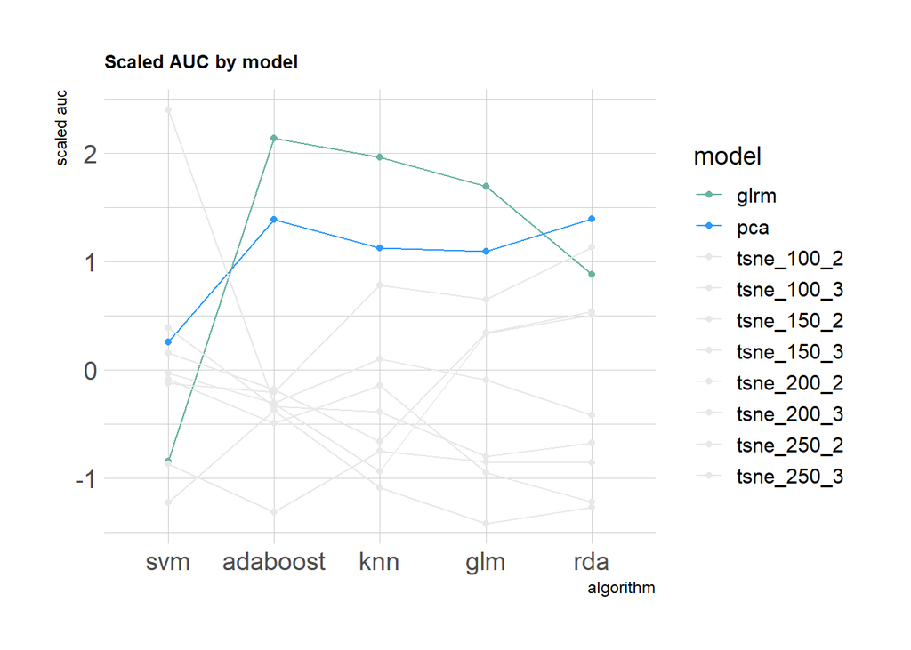

```r
glm_results %>%
  bind_rows(svm_results) %>%
  bind_rows(rda_results) %>%
  bind_rows(adaboost_results) %>%
  bind_rows(knn_results) %>%
  select(-max_auc) %>%
  spread(key = alg, value = mean_auc) %>%
  ggparcoord(columns = 2:6, groupColumn = 1, order = "anyClass",
             showPoints = TRUE,
             title = "Scaled AUC by model",
             alphaLines = 1
  ) +
  scale_color_manual(values=c( "#69b3a2", "#2E9AFE",rep("#E8E8E8", 8)) ) +
  theme_ipsum(base_size = 14)+
  theme(
    plot.title = element_text(size=10)
  ) +
  xlab("algorithm") + ylab("scaled auc")
```

# 7 Trying other models

Since the database was chosen, other algorithms were applied to the database produced by GLRM, to add other models that may be useful for our ensemble model. Ten models were selected (in addition to those that have already been applied previously) provided by the Caret package. default tunegrid from caret and 5 fold cross-validation was used:

```r
models <- c('bartMachine','AdaBoost.M1','adaboost',
            'AdaBag', 'bagFDA',
            'gamboost',
            'LogitBoost', 'blackboost', 'C5.0',
            'cforest')

data <- data.frame(dim_red_data[10])[,-12]

  set.seed(666)

  trainRowNumbers <- createDataPartition(shuffle(data$exam), p=0.80, list=FALSE)

  # Create the training  dataset

  train <- data[trainRowNumbers,]

  # Create the test dataset

  test <- data[-trainRowNumbers,]

train_fix <- train

overfit_data <- data.frame(model = "x",
                           train = 1,
                           test = 1)

for (model_name in models){

  set.seed(666)

  model <- train(
    exam ~ ., train_fix ,
    method = model_name,
    preProcess = c("scale", "center"),
    trControl = trainControl(
      method = "cv",
      search = "grid",
      number = 5,
      verboseIter = TRUE,
      classProbs = TRUE,
      summaryFunction = twoClassSummary,
      sampling = "smote"
    ),
    metric = 'ROC')

  test$prob <- caret::predict.train(model, test, type = "prob")[,2]
  train$prob <- caret::predict.train(model, train, type = "prob")[,2]


  pred <- prediction(test$prob, test$exam)
  perf <- performance(pred,"auc")
  test_perf<-  perf@y.values[[1]]

  pred <- prediction(train$prob, train$exam)
  perf <- performance(pred,"auc")
  train_perf<- perf@y.values[[1]]

  overfit_data <- rbind(overfit_data, c(model_name, train_perf, test_perf))

}

overfit_data <- overfit_data[-1,]
overfit_data$model <- models

overfit_data <- overfit_data %>%
  mutate(train = as.numeric(train),
         test = as.numeric(test),
         dif = train - test)
```

The table below shows the AUC values in the training and test set, plus a column of the difference between the AUC in training with the AUC in the test set. The table is ordered from the highest AUC value in the test set to the lowest:

```r
kable(overfit_data %>%
  arrange(desc(test))) %>%
  kable_styling(bootstrap_options = c("striped", "hover", "condensed", "responsive"))
```

| model | train | test | dif |
| --- | --- | --- | --- |
| cforest | 0.7842940 | 0.6894148 | 0.0948792 |
| adaboost | 0.8361858 | 0.6758348 | 0.1603509 |
| AdaBoost.M1 | 0.7180874 | 0.6617559 | 0.0563316 |
| gamboost | 0.6688069 | 0.6570233 | 0.0117837 |
| bagFDA | 0.6728712 | 0.6475383 | 0.0253329 |
| C5.0 | 0.6840408 | 0.6465878 | 0.0374530 |
| blackboost | 0.6801018 | 0.6404770 | 0.0396248 |
| AdaBag | 0.6619285 | 0.6348890 | 0.0270395 |
| LogitBoost | 0.6552581 | 0.6070359 | 0.0482222 |
| bartMachine | 0.2556266 | 0.3370679 | -0.0814413 |

What is observed is that some models, despite presenting an excellent performance in the test set, have a great difference from the training set. I selected the models with a difference (in module) less than 0.05 and with a relatively good performance on test set. The Gamboost model obtained a good performance (compared to the other models) and obtained little difference between the training and test set the same goes for the AdaBag, bagFDA, C5.0, Blackboost and LogitBoost models, so these models were selected to be used in the ensemble model.

# 8 Applying selected models

First, the database was separated again in training and testing (using the same seed as the previous applications):

```r
# Create training and test data

data <- data.frame(dim_red_data[10])[,-12]

set.seed(666)
trainRowNumbers <- createDataPartition(shuffle(data$exam), p=0.80, list=FALSE)

# Create the training  dataset

train <- data[trainRowNumbers,]

# Create the test dataset

test <- data[-trainRowNumbers,]
```

Finally, given that the database was chosen (GLRM) and the models as well, the models were applied to the training set, all of which were applied with 5 fold cross validation, with pre-processing of the data (scale and center) , using oversampling (SMOTE), optimizing the AUC metric and in some models the default tunegrid was used and in other models a custom tunegrid was used:

```r
# bagFDA



set.seed(666)

bagFDA_model <- train(
  exam ~ ., train ,
  method = "bagFDA",
  preProcess = c("scale", "center"),
  trControl = trainControl(
    method = "cv",
    search = "grid",
    number = 5,
    verboseIter = TRUE,
    classProbs = TRUE,
    summaryFunction = twoClassSummary,
    sampling = "smote"
  ),
  metric = 'ROC')

# Adabag



set.seed(666)

adabag_model <- train(
  exam ~ ., train ,
  method = "AdaBag",
  preProcess = c("scale", "center"),
  trControl = trainControl(
    method = "cv",
    search = "grid",
    number = 5,
    verboseIter = TRUE,
    classProbs = TRUE,
    summaryFunction = twoClassSummary,
    sampling = "smote"
  ),
  metric = 'ROC')

# C50



set.seed(666)

C5_model <- train(
  exam ~ ., train ,
  method = "C5.0",
  preProcess = c("scale", "center"),
  trControl = trainControl(
    method = "cv",
    search = "grid",
    number = 5,
    verboseIter = TRUE,
    classProbs = TRUE,
    summaryFunction = twoClassSummary,
    sampling = "smote"
  ),
  metric = 'ROC')




# GAMBOOST



set.seed(666)

gamboost_model <- train(
  exam ~ ., train ,
  method = "gamboost",
  preProcess = c("scale", "center"),
  trControl = trainControl(
    method = "cv",
    search = "grid",
    number = 5,
    verboseIter = TRUE,
    classProbs = TRUE,
    summaryFunction = twoClassSummary,
    sampling = "smote"
  ),
  metric = 'ROC')

# RDA

tuneGrid <- expand.grid(
  lambda = seq(0, 1, 0.1),
  gamma = seq(0, 1, 0.1))


set.seed(666)

rda_model <- train(
  exam ~ ., train ,
  method = "rda",
  preProcess = c("scale", "center"),
  trControl = trainControl(
    method = "cv",
    search = "grid",
    number = 5,
    verboseIter = TRUE,
    classProbs = TRUE,
    summaryFunction = twoClassSummary,
    sampling = "smote"
  ),
  tuneGrid = tuneGrid,
  metric = 'ROC')

# Logit boost estimation


set.seed(666)

logit_model <- train(
  exam ~ ., train ,
  method = "LogitBoost",
  preProcess = c("scale", "center"),
  trControl = trainControl(
    method = "cv",
    search = "grid",
    number = 5,
    verboseIter = TRUE,
    classProbs = TRUE,
    summaryFunction = twoClassSummary,
    sampling = "smote"
  ),
  metric = 'ROC')

# Ada estimation


set.seed(666)

ada_model <- train(
  exam ~ ., train ,
  method = "ada",
  preProcess = c("scale", "center"),
  trControl = trainControl(
    method = "cv",
    search = "grid",
    number = 5,
    verboseIter = TRUE,
    classProbs = TRUE,
    summaryFunction = twoClassSummary,
    sampling = "smote"
  ),
  metric = 'ROC')

# Blackboost estimation

set.seed(666)

blackboost_model <- train(
  exam ~ ., train ,
  method = "blackboost",
  preProcess = c("scale", "center"),
  trControl = trainControl(
    method = "cv",
    search = "grid",
    number = 5,
    verboseIter = TRUE,
    classProbs = TRUE,
    summaryFunction = twoClassSummary,
    sampling = "smote"
  ),
  metric = 'ROC')


# GLM

tuneGrid <- expand.grid(
  lambda = seq(0, 1, 0.01),
  alpha = seq(0, 1, 0.1))


set.seed(666)

glm_model <- train(
  exam ~ ., train ,
  method = "glmnet",
  preProcess = c("scale", "center"),
  trControl = trainControl(
    method = "cv",
    search = "grid",
    number = 5,
    verboseIter = TRUE,
    classProbs = TRUE,
    summaryFunction = twoClassSummary,
    sampling = "smote"
  ),
  tuneGrid = tuneGrid,
  metric = 'ROC')

# KNN

tuneGrid <- expand.grid(
  k = c(1:70))


set.seed(666)

knn_model <- train(
  exam ~ ., train ,
  method = "knn",
  preProcess = c("scale", "center"),
  trControl = trainControl(
    method = "cv",
    search = "grid",
    number = 5,
    verboseIter = TRUE,
    classProbs = TRUE,
    summaryFunction = twoClassSummary,
    sampling = "smote"
  ),
  tuneGrid = tuneGrid,
  metric = 'ROC')

# svm

set.seed(666)

svm_model <- train(
  exam ~ ., train,
  method = "svmRadial",
  preProcess = c("scale", "center"),
  trControl = trainControl(
    method = "cv",
    search = "grid",
    number = 5,
    verboseIter = TRUE,
    classProbs = TRUE,
    summaryFunction = twoClassSummary,
    sampling = "smote"
  ),
  metric = 'ROC')
```

Then, the models were used to predict probabilities in both the training set and the test set, so that these probabilities can be used in the final model as input:

```r
# Bringing the probabilities

# - Test

test$prob_logit <- caret::predict.train(logit_model, test, type = "prob")[,2]
test$prob_knn <- caret::predict.train(knn_model, test, type = "prob")[,2]
test$prob_glm <- caret::predict.train(glm_model, test, type = "prob")[,2]
test$prob_rda <- caret::predict.train(rda_model, test, type = "prob")[,2]
test$prob_ada <- caret::predict.train(ada_model, test, type = "prob")[,2]
test$prob_blackboost <- caret::predict.train(blackboost_model, test, type = "prob")[,2]
test$prob_bagfda <- caret::predict.train(bagFDA_model, test, type = "prob")[,2]
test$prob_gamboost <- caret::predict.train(gamboost_model, test, type = "prob")[,2]
test$prob_svm <- caret::predict.train(svm_model, test, type = "prob")[,2]
test$prob_c50 <- caret::predict.train(C5_model, test, type = "prob")[,2]
test$prob_adabag <- caret::predict.train(adabag_model, test, type = "prob")[,2]


# - Train

train$prob_logit <- caret::predict.train(logit_model, train, type = "prob")[,2]
train$prob_knn <- caret::predict.train(knn_model, train, type = "prob")[,2]
train$prob_glm <- caret::predict.train(glm_model, train, type = "prob")[,2]
train$prob_rda <- caret::predict.train(rda_model, train, type = "prob")[,2]
train$prob_ada <- caret::predict.train(ada_model, train, type = "prob")[,2]
train$prob_blackboost <- caret::predict.train(blackboost_model, train, type = "prob")[,2]
train$prob_bagfda <- caret::predict.train(bagFDA_model, train, type = "prob")[,2]
train$prob_gamboost <- caret::predict.train(gamboost_model, train, type = "prob")[,2]
train$prob_svm <- caret::predict.train(svm_model, train, type = "prob")[,2]
train$prob_c50 <- caret::predict.train(C5_model, train, type = "prob")[,2]
train$prob_adabag <- caret::predict.train(adabag_model, train, type = "prob")[,2]
```

The AUC for each of the models in the training set and test set was calculated:

```r
train_perf <- c()
test_perf <- c()

for (i in c(12:22)){


  pred <- prediction(test[,i], test$exam)
  perf <- performance(pred,"auc")
  test_perf<- c(test_perf, perf@y.values[[1]])

  pred <- prediction(train[,i], train$exam)
  perf <- performance(pred,"auc")
  train_perf<- c(train_perf, perf@y.values[[1]])



}

overfit <- data.frame(model = colnames(test[,c(12:22)]),
                      train = train_perf,
                      test = test_perf)


overfit <- overfit %>%
  mutate(dif = test - train)
```

The table below shows the difference in AUC between training and testing of this application of the algorithms:

```r
kable(overfit %>%
  arrange(desc(dif))) %>%
    kable_styling(bootstrap_options = c("striped", "hover", "condensed", "responsive"))
```

| model | train | test | dif |
| --- | --- | --- | --- |
| prob_rda | 0.6334759 | 0.6420057 | 0.0085297 |
| prob_gamboost | 0.6688069 | 0.6570233 | -0.0117837 |
| prob_glm | 0.6377420 | 0.6200021 | -0.0177399 |
| prob_bagfda | 0.6728712 | 0.6475383 | -0.0253329 |
| prob_adabag | 0.6619285 | 0.6348890 | -0.0270395 |
| prob_knn | 0.7291933 | 0.6958820 | -0.0333113 |
| prob_c50 | 0.6840408 | 0.6465878 | -0.0374530 |
| prob_blackboost | 0.6801018 | 0.6404770 | -0.0396248 |
| prob_ada | 0.7062812 | 0.6638152 | -0.0424660 |
| prob_logit | 0.6552581 | 0.6070359 | -0.0482222 |
| prob_svm | 0.6990568 | 0.5991430 | -0.0999138 |

What is observed is that the model with the worst performance in the test set and with the greatest difference between training and test was the SVM, so this model was not used in the ensemble model.

# 9 Ensemble model

Finally, to create the final model, a new set of training and testing was created using the probabilities estimated by the algorithms:

```r
# - Creating new train and test data

ensemble_train <- train[,c(11, 12:19, 21, 22)]
ensemble_test <- test[,c(11, 12:19, 21, 22)]
```

One of the things expected and observed in the database is that the features of the model are highly correlated, as can be seen in the plot below:

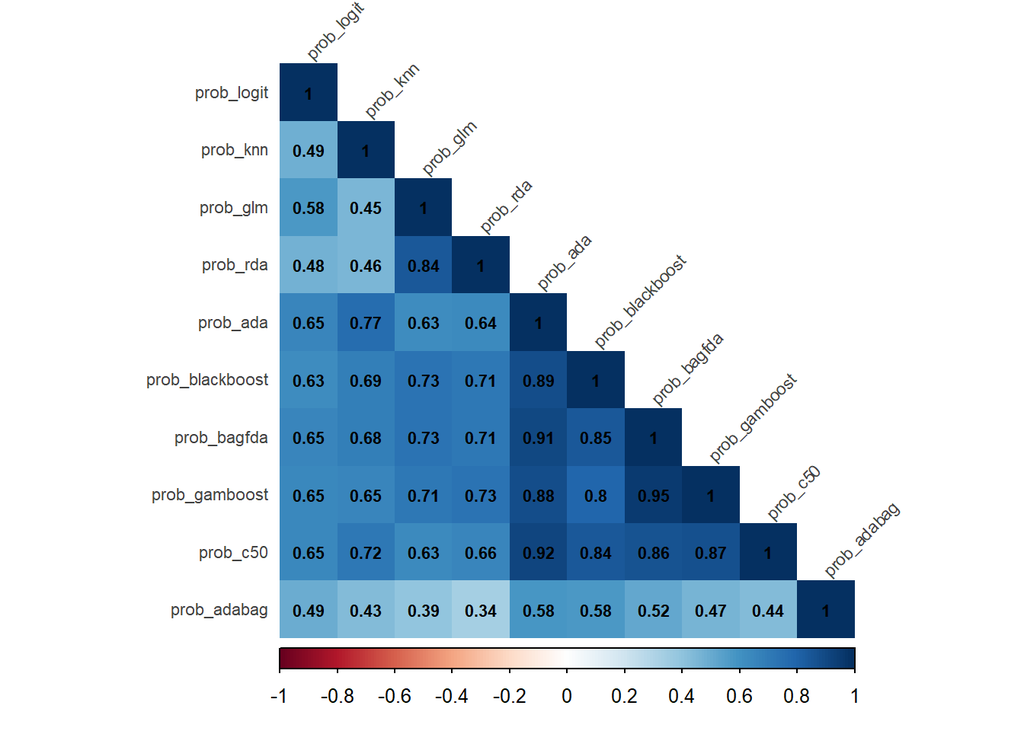

```r
cor_matrix <- cor(ensemble_train[,-1])
corrplot(cor_matrix, method = "shade", type = "lower", tl.col = '#424242', tl.srt = 45,
         addCoef.col = "black", tl.cex = 0.7, number.cex = 0.7)
```

Given the high correlation, I decided not to use parametric algorithms with different assumptions related to distribution, multicollinearity, etc. In this way, I opted for a non-parametric algorithm that will not have serious problems with multicollinearity: knn. The model was applied using the same tunegrid as the previous knn application and the same configuration as the other algorithm applications:

```r
tuneGrid <- expand.grid(
  k = c(1:70))

set.seed(666)

ensemble_model <- train(
  exam ~ ., ensemble_train ,
  method = "knn",
  preProcess = c("scale", "center"),
  trControl = trainControl(
    method = "cv",
    search = "grid",
    number = 5,
    verboseIter = TRUE,
    classProbs = TRUE,
    summaryFunction = twoClassSummary,
    sampling = "smote"
  ),
  tuneGrid = tuneGrid,
  metric = 'ROC')
```

The plot below shows the AUC according to each K value during training, where the maximum value of AUC is 0.7253, with k = 67:

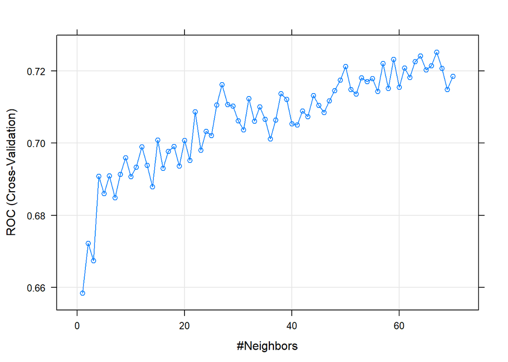

```r
# - Hyperparamenter results plot

plot(ensemble_model)
```

Then, the Ensemble Model already trained was applied to the test set:

```r
ensemble_test$prediction <- caret::predict.train(ensemble_model, test, type = "prob")[,2]
ensemble_train$prediction <- caret::predict.train(ensemble_model, train, type = "prob")[,2]
```

The plot below shows the distribution of probabilities estimated by the algorithms in the test set colored by the labels, in order to observe how well the algorithm managed to separate the two distributions:

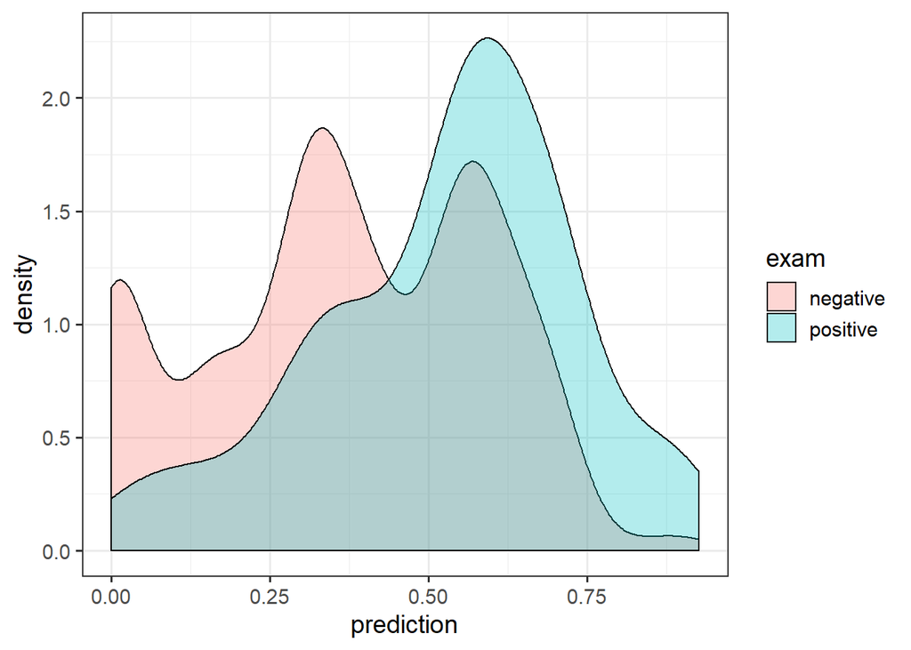

```r
# - ROC Curve


ggplot(ensemble_test, aes(x = prediction, fill = exam)) + geom_density(alpha = 0.3) + theme_bw(base_size = 14)
```

Visually, the model separated the two labels relatively well, but to validate this we will use the AUC, in addition to being useful to observe if there was overfitting. The plot below shows the ROC curve:

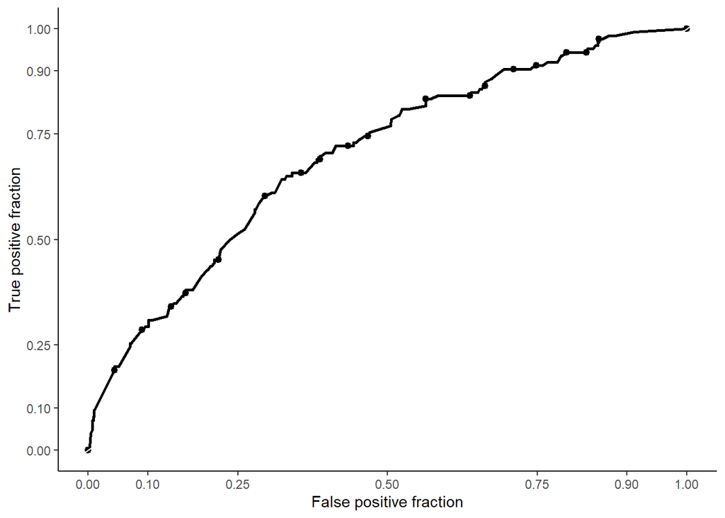

```r
# - ROC Curve


rocplot <- ggplot(ensemble_test, aes(m = prediction, d = exam))+ geom_roc(n.cuts=20,labels=FALSE)
rocplot + style_roc(theme = theme_grey) + geom_rocci(fill="pink") + theme_classic()
```

It is possible to observe in the code below that the AUC in the test set is 0.7012:

```r
# - ROC Value


pred <- prediction(ensemble_test$prediction, ensemble_test$exam)
perf <- performance(pred,"auc")

perf@y.values
```

```
## [[1]]
## [1] 0.7012483
```

Comparing the result with the results obtained by the other Kernels in Kaggle, it is an interesting result, mainly considering the number of observations we have, the imbalance of the database and mainly the missing information from the data, such as gender information, symptoms etc. In addition, the difference in AUC between training and testing was low, indicating a good generalizability of the model.

# 10 Conclusion

```r
# - Tradeoff between specificity and sensitivity

specificity <- c()
sensitivity <- c()
accuracy <- c()

for (i in seq(0.1,0.9,0.01)){

  test <- ensemble_test %>%
    mutate(class = ifelse(prediction > i, "positive", "negative"))

  conf <- table(test$exam, test$class)

  conf

  conf[1,1]/sum(conf[1,])

  specificity <- c(specificity, conf[2,2]/sum(conf[2,]))
  sensitivity <- c(sensitivity, conf[1,1]/sum(conf[1,]))
  accuracy <- c(accuracy, (conf[1,1] + conf[2,2])/sum(conf))
}

data <- data.frame(prob = seq(0.1,0.9,0.01),
                   sensitivity = sensitivity,
                   specificity = specificity,
                   accuracy = accuracy)



data <- data %>%
  gather(key = "metric", value = "value", -prob)
```

The plot below shows the different values of accuracy, sensitivity and specificity calculated for different values of probabilities up to 0.9:

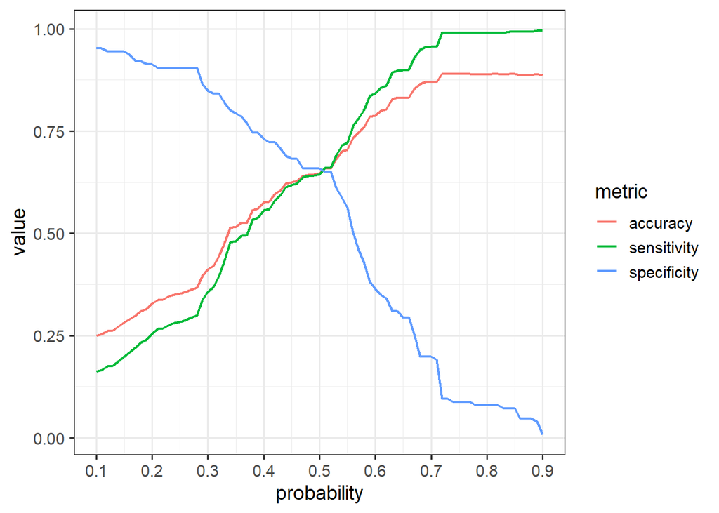

```r
ggplot(data, aes(x = prob, y = value, color = metric)) + geom_line(size = 0.8) +
  theme_bw(base_size = 14) + scale_x_continuous(breaks = seq(0,1,0.1)) +
  labs(x = "probability", y = "value")
```

Finally, another possibility is not to favor specificity or sensitivity, but for a balanced test. If this is the objective, it is possible to choose a probability equivalent to 0.52. In this case, the algorithm will correctly predict 65.96% of the cases that have the disease and 65% of the cases that do not have the disease.